# Exercise 3

Reister L. Ruedas

**Note:** We will assume that the data file `expenditures_lec2.csv` is in your working directory.

Problem 1: Load the CSV file `expenditures_lec2.csv` into memory, using the command `read.file()` or `read.csv()` as described in lecture. Save the result as a variable.

```r
# Fill in, with comments added:
expenditures <- read.csv(file = 'expenditures_lec2.csv')
expenditures
```

```
##    household.id    region        population.size income.class family.size
## 1       2227674   Midwest             4 million+ $20K-$29,999           1
## 2       2227914 Northeast             4 million+        $70K+           3
## 3       2228025     South       125-329 thousand $50K-$69,999           4
## 4       2228115 Northeast             4 million+        $70K+           4
## 5       2228274      West       125-329 thousand $15K-$19,999           3
## 6       2228385      West             4 million+   $5K-$9,999           2
## 7       2228494   Midwest       125-329 thousand $15K-$19,999           1
## 8       2228735     South       125-329 thousand $40K-$49,999           2
## 9       2228775 Northeast             4 million+ $50K-$69,999           1
## 10      2228915 Northeast             4 million+ $20K-$29,999           3
## 11      2229075 Northeast             4 million+ $30K-$39,999           5
## 12      2229094     South             4 million+   $5K-$9,999           1
## 13      2229365   Midwest less than 125 thousand $40K-$49,999           2
## 14      2229544   Midwest             4 million+ $50K-$69,999           5
```

[output cut: 77 more lines]

```r
library(plyr)
library(ggplot2)
```

Problem 2: Create a scatter plot showing how `healthcare` costs behave as a function of the `age.respondent` variable. Don’t forget to load any libraries you need!

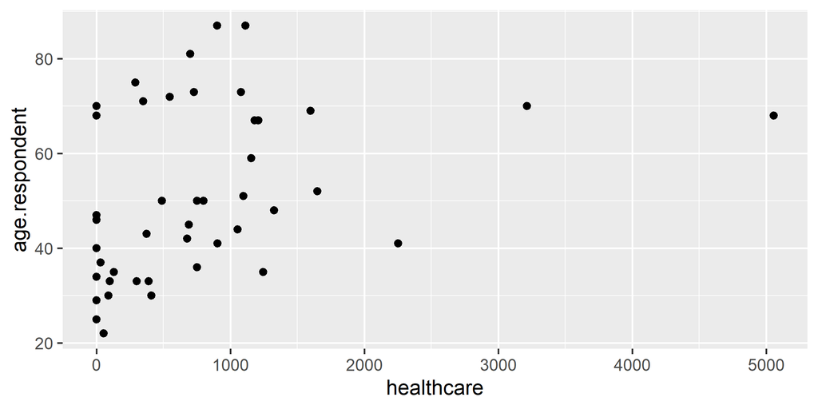

```r
# Fill in, with comments added:
ggplot(data = expenditures, mapping = aes(x = healthcare, y = age.respondent)) + geom_point()
```

Problem 3: Create a bar chart showing how many rows in the data set are in each `region`.

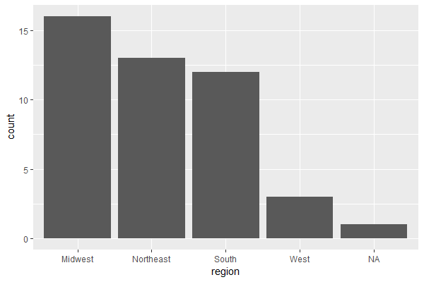

```r
# Fill in, with comments added:
ggplot(expenditures, aes(x = region)) + geom_bar()
```

Problem 4: Use functions from lecture 2 (such as the `plyr` package) to compute the fraction (or percentage) of households that are in each `region`, instead of the raw counts. Then plot this as a bar chart.

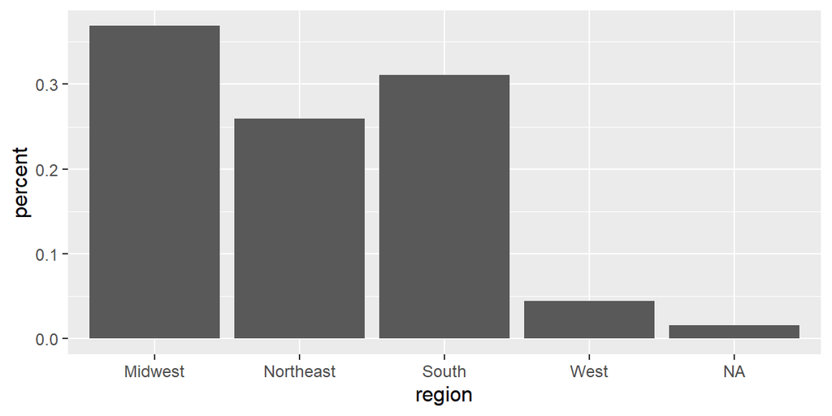

```r
# Fill in, with comments added:
total = ddply(expenditures, "region", summarize, households = sum(housing))
percentage = ddply(total, "region", summarize, percent = households/ sum(expenditures$housing))

ggplot(percentage, aes(x = region, y = percent)) + geom_bar(stat = "identity")
```

Problem 5: Remake the plot of problem 2, showing `healthcare` costs, but this time color-code the points to distinguish between those which spent over and under $3000 on health care.

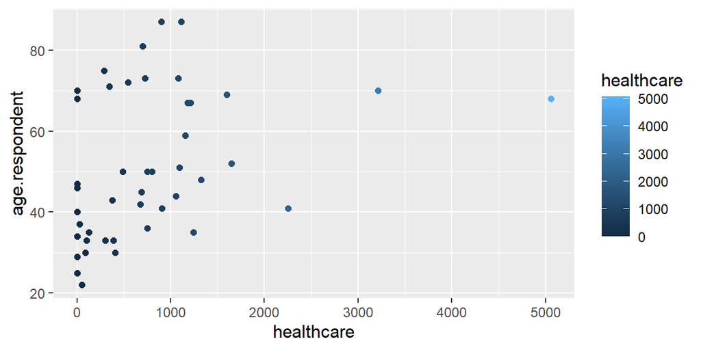

```r
# Fill in, with comments added:
ggplot(data = expenditures, mapping = aes(x = healthcare, y = age.respondent, color = healthcare)) + geom_point()
```